# Contents

1. Degree
2. Betweenness
3. Closeness
4. Eigenvector centrality
5. PageRank
6. Community
7. Similarity

```python
import networkx as nx
import numpy as np
import matplotlib as mpl
import matplotlib.pyplot as plt
%matplotlib inline

nx.__version__, mpl.__version__
```

```
('3.1', '3.5.2')
```

This tutorial will use a coappearance network of characters from Les Misérables ([Knuth, 1993](https://www-cs-faculty.stanford.edu/~knuth/sgb.html)). It contains 77 characters, and an edge between two characters mean that they appear in the same scene at least once. You can download the dataset from [Mark Newman's website](http://www-personal.umich.edu/~mejn/netdata/). (He is a famous network scientist and the author of one of your textbooks *Networks: An Introduction*.)

As mentioned in Tutorial 1, NetworkX names nodes of a GML file with their `label` by default, whereas you can rename them with `relabel_nodes`. If you simply want to rename them with integers, you can use `convert_node_labels_to_integers`.

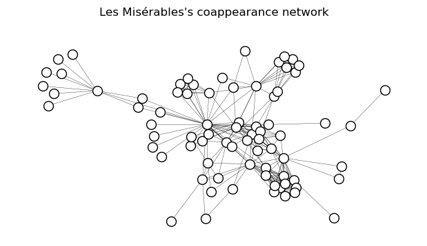

```python
lesmis = nx.read_gml('datasets/lesmis.gml')
lesmis = nx.convert_node_labels_to_integers( # save the original labels as node
    lesmis, label_attribute='name')          # attributes 'name' at the same time
lesmis.graph['pos'] = nx.spring_layout( # this layout looks somewhat nicer
    lesmis, seed=5056)                  # than the Kamada-Kawai layout

def draw_lesmis(centrality_func, label=None, vmin=None, vmax=None):
    ''' centrality_func is a function that receives a graph
        and returns a dict like {node: its centrality_value}
    '''
    plt.figure(figsize=(6, 3))
    if centrality_func is None:
        nx.draw(lesmis, pos=lesmis.graph['pos'], node_color='w',
                node_size=100, edgecolors='k', width=.25)
    else:
        centrality_dict = centrality_func(lesmis)
        node_color = [centrality_dict[n] for n in lesmis]
        if vmin is None: vmin = min(node_color)
        if vmax is None: vmax = max(node_color)

        cmap = mpl.colors.LinearSegmentedColormap.from_list('', ['w','r'])
        norm = mpl.colors.Normalize(vmin=vmin, vmax=vmax)
        smap = mpl.cm.ScalarMappable(norm, cmap)
        smap.set_array([])

        nx.draw(lesmis, pos=lesmis.graph['pos'],
                node_size=100, edgecolors='k', width=.25,
                node_color=node_color, cmap=cmap, vmin=vmin, vmax=vmax)
        plt.colorbar(smap, fraction=0.045, pad=.05, aspect=50, label=label)
    plt.title('Les Misérables\'s coappearance network\n')

draw_lesmis(None)
```

This is a weighted network—an edge's `value` records in how many scenes two characters appear together—but I am going to ignore the weights.

NetworkX has in fact provided this dataset, so you may replace the first line `lesmis = nx.read_gml(datasets/lesmis.gml)` with `lesmis = nx.les_miserables_graph()`, but they name the weight explicitly as `weight`. This is why I prefer using Newman's file instead. Naming weight as `weight` can cause some unwanted behaviours in certain functions because they are implemented to first detect whether a network has an edge attribute called `weight`.

This tutorial will also use the following three toy networks, which are also shown on our lecture notes. You can therefore use them for cross-reference.

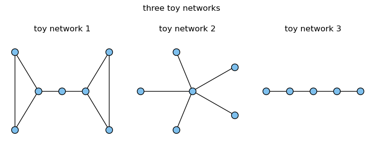

```python
toy1 = nx.disjoint_union(nx.cycle_graph(3), nx.cycle_graph(3))
toy1.add_edges_from([(6, 0), (6, 3)])
toy2 = nx.star_graph(5)
toy3 = nx.path_graph(5)
toys = [toy1, toy2, toy3]

toy1.graph['pos'] = {0: (1, 0), 1: (0, 1), 2: (0, -1),
                     3: (3, 0), 4: (4, 1), 5: (4, -1), 6: (2, 0)}
toy2.graph['pos'] = nx.shell_layout(toy2, [[0], [1, 2, 3, 4, 5]])
toy3.graph['pos'] = {n: (n, 0) for n in range(5)}

def _draw_toys(centrality_func, title, toys):
    fig, ax = plt.subplots(1, 3, figsize=(3*(3+.1*2), 2.5))
    plt.subplots_adjust(wspace=.1)

    for i, toy in enumerate(toys):
        if centrality_func is None:
            nx.draw(toy, pos=toy.graph['pos'], ax=ax[i],
                    node_size=100, node_color='#7ec0ee', edgecolors='k')
        else:
            centrality_dict = centrality_func(toy)
            labels = {n: '0' if k<1e-6 else ('%g' % round(k, 2)).lstrip('0')
                      for n, k in centrality_dict.items()}

            nx.draw_networkx_labels(toy, pos=toy.graph['pos'],  ax=ax[i],
                                    labels=labels, font_size=8)
            nx.draw(toy, pos=toy.graph['pos'],  ax=ax[i],
                    node_size=[centrality_dict[n]*500+200 for n in toy],
                    node_color='#7ec0ee', edgecolors='k')
        ax[i].set_title('toy network %s\n' % (i+1))
    fig.suptitle(title, y=1.2)

draw_toys = lambda cfunc, title: _draw_toys(cfunc, title, toys=toys)
draw_toys(None, 'three toy networks')
```

In the following sections, $N$ always denotes the number of nodes on any network, and all centrality measures are defined for simple networks except in Section 5.

# 1. Degree

A node's degree $k$ is the number of its adjacent nodes. You can get it with `degree`, which is both a network's attribute and a function. The returned object `DegreeView` resembles `dict`; but unlike `dict`, you will get some tuples in the form of `(node, its_degree)` if you iterate over `DegreeView`.

```python
(toy1.degree,     # as an attribute
 nx.degree(toy1), # as a function, but same results

 toy1.degree[0], # just treat DegreeView as dict
 toy1.degree(0), # this works, but I rarely use it

 list(toy1.degree)) # a list of tuples
```

```
(DegreeView({0: 3, 1: 2, 2: 2, 3: 3, 4: 2, 5: 2, 6: 2}),
 DegreeView({0: 3, 1: 2, 2: 2, 3: 3, 4: 2, 5: 2, 6: 2}),
 3,
 3,
 [(0, 3), (1, 2), (2, 2), (3, 3), (4, 2), (5, 2), (6, 2)])
```

On one hand, it may look better to normalize $k$ with $N-1$ so that it is always within the range $\left[0, 1\right]$. The function `degree_centrality` returns the normalized degree

\begin{align} \hat{k} = \dfrac{k}{N-1}\,. \end{align}

On the other hand, **normalization does not really matter if you are dealing with only one network** because the normalization constant merely rescales all degrees in a uniform way. This is true for all centrality measures.

```python
nx.degree_centrality(toy1)
```

```
{0: 0.5,
 1: 0.3333333333333333,
 2: 0.3333333333333333,
 3: 0.5,
 4: 0.3333333333333333,
 5: 0.3333333333333333,
 6: 0.3333333333333333}
```

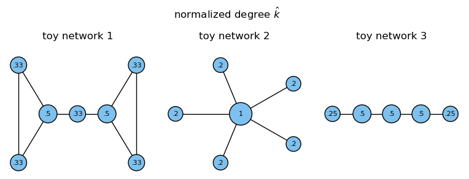

```python
draw_toys(nx.degree_centrality, 'normalized degree $\hat{k}$')
```

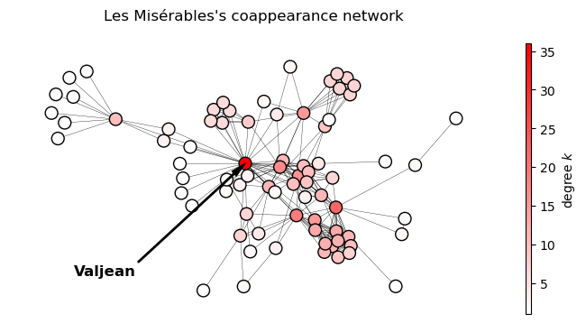

```python
draw_lesmis(lambda G: {n: k for n, k in G.degree}, 'degree $k$')

centre = max(lesmis.degree, key=lambda n_k: n_k[1])[0]
plt.annotate(lesmis.nodes[centre]['name'], lesmis.graph['pos'][centre],
             (plt.xlim()[0]*.75, plt.ylim()[0]*.75),
             ha='left', va='bottom', size=12, weight='bold',
             arrowprops={'width': 1, 'headwidth': 5, 'facecolor': 'k'})
plt.show()
```

The highest-degree node in the coappearance network reprsents Jean Valjean, the main character in Les Misérables. You will see that other measures also regard him as a centre.

# 2. Betweenness

You can compute node $i$'s betweenness with `betweenness_centrality`. By default, it returns the normalized value

\begin{align} \hat{b} _ i = \dfrac{2}{\left(N-1\right)\left(N-2\right)} \underbrace{ \sum_{s\neq i} \sum_{t\neq i} \dfrac{g_{st}{\left(i\right)}}{g_{st}} } _ {b_i} \,; \end{align}

if you want to get its unnormalized counterpart $b_i$, you need to set `normalized=False`. While $g_{st}$ counts the geodesics from source $s$ to target $t$, $g_{st}{\left(i\right)}$ counts the ones from $s$ to $t$ via $i$. Hence, a node has a high betweenness if it is "between many nodes", meaning that its removal will rewire many geodesics.

```python
(nx.betweenness_centrality(toy1), # normalized=True
 nx.betweenness_centrality(toy1, normalized=False))
```

```
({0: 0.5333333333333333,
  1: 0.0,
  2: 0.0,
  3: 0.5333333333333333,
  4: 0.0,
  5: 0.0,
  6: 0.6},
 {0: 8.0, 1: 0.0, 2: 0.0, 3: 8.0, 4: 0.0, 5: 0.0, 6: 9.0})
```

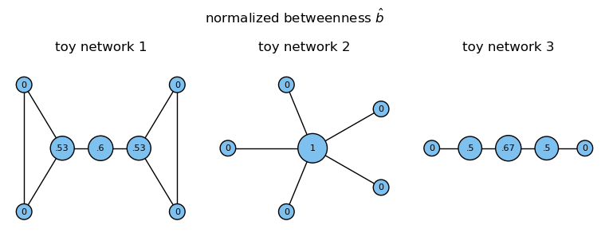

```python
draw_toys(nx.betweenness_centrality, 'normalized betweenness $\hat{b}$')
```

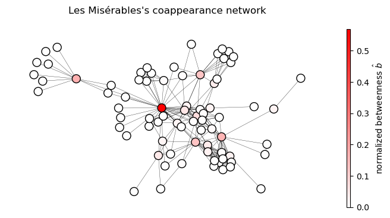

```python
draw_lesmis(nx.betweenness_centrality, 'normalized betweenness $\hat{b}$')
```

### Current flow betweenness.

The concept "betweenness" was first formulated by Freeman ([1978](https://www.sciencedirect.com/science/article/abs/pii/0378873378900217); who appears on our lecture notes in the term "Freeman centralization"). Since then, various kinds of modification have been proposed. An arguably more useful alternative is current flow beteweenness, which can be computed with `current_flow_betweenness_centrality`.

The "current" in its name refers to electric current because it is defined by treating the edges as resistors and then considering the passage of current along them ([Newman, 2005](https://www.sciencedirect.com/science/article/abs/pii/S0378873304000681)). If you are intersted, you may read Newman's derivation, but it is quite involved. (By the way, Newman named his quantity as "**random walk betweenness**" instead.)

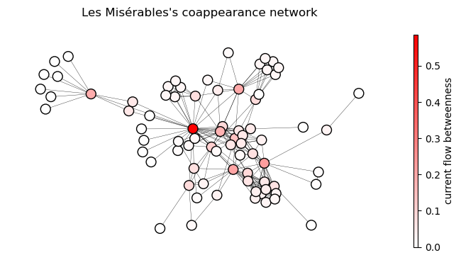

```python
draw_lesmis(nx.current_flow_betweenness_centrality, 'current flow betweenness')
```

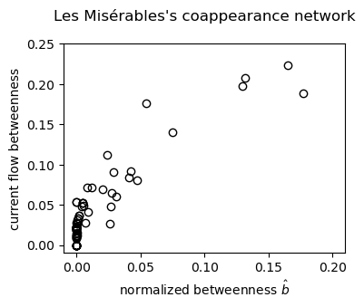

```python
plt.figure(figsize=(4, 3))
plt.plot(nx.betweenness_centrality(lesmis).values(),
         nx.current_flow_betweenness_centrality(lesmis).values(),
         'ko', markerfacecolor='none')
plt.xlabel('normalized betweenness $\hat{b}$')
plt.ylabel('current flow betweenness')
plt.title('Les Misérables\'s coappearance network\n')
plt.xlim(-.01, .21); plt.ylim(-.01, .25)
plt.show() # current flow betweenness can differentiate
           # nodes that all have zero betweenness
```

# 3. Closeness

Let $d_{ij}$ be the geodesic distance from node $i$ to node $j$. Node $i$'s closeness is defined as

\begin{align} c_i = \dfrac{1}{ \sum_j d_{ij} }\,. \end{align}

Therefore, a node has a high closeness if it has a short distance to many nodes. You can compute a node's closeness with `closeness centrality`, but it always returns the normalized value $\hat{c}_i = \left(N-1\right) c_i$.

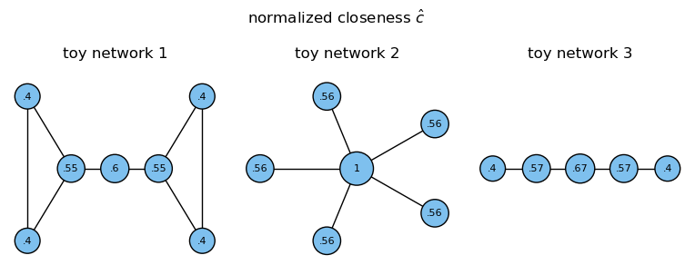

```python
draw_toys(nx.closeness_centrality, 'normalized closeness $\hat{c}$')
```

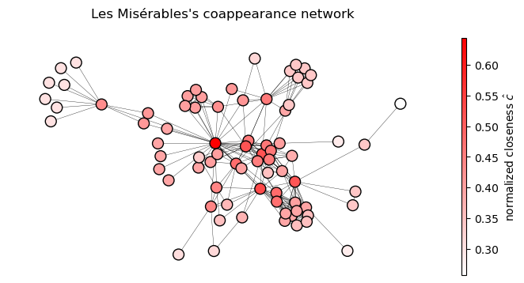

```python
draw_lesmis(nx.closeness_centrality, 'normalized closeness $\hat{c}$')
```

### Harmonic closeness.

On a disconnected network, you may want to use the harmonic closeness

\begin{align} h_i = \sum_j \dfrac{1}{d_{ij}} \end{align}

instead because the distance $d_{ij}$ is defined to be infinitely long when $i$ cannot reach $j$. You can compute it with `harmonic_centrality`.

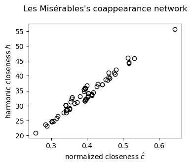

```python
plt.figure(figsize=(4, 3))
plt.plot(nx.closeness_centrality(lesmis).values(),
         nx.harmonic_centrality(lesmis).values(),
         'ko', markerfacecolor='none')
plt.xlabel('normalized closeness $\hat{c}$')
plt.ylabel('harmonic closeness $h$')
plt.title('Les Misérables\'s coappearance network\n')
plt.show() # almost proportional on a connecetd network
```

### Current flow closeness.

Similar to current flow betweennes, current flow closeness is defined by treating the edges as resistors and then replacing the distance $d_{ij}$ between two nodes with their **resistance distance**. You can compute it with `current_flow_closeness`.

It was originally named as "**information centrality**" and defined with ordinary concepts of graph theory ([Stephenson and Zelen, 1989](https://www.sciencedirect.com/science/article/abs/pii/0378873389900166)). However, the definition was soon found out to be closely related to circuit theory ([Altmann, 1993](https://www.sciencedirect.com/science/article/abs/pii/037887339390019H)).

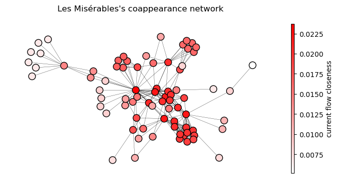

```python
draw_lesmis(nx.current_flow_closeness_centrality, 'current flow closeness')
```

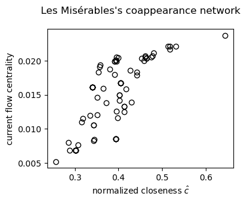

```python
plt.figure(figsize=(4, 3))
plt.plot(nx.closeness_centrality(lesmis).values(),
         nx.current_flow_closeness_centrality(lesmis).values(),
         'ko', markerfacecolor='none')
plt.xlabel('normalized closeness $\hat{c}$')
plt.ylabel('current flow centrality')
plt.title('Les Misérables\'s coappearance network\n')
plt.show()
```

# 4. Eigenvector centrality

Let $v_i$ be node $i$'s eigenvector centrality. It satisfies the equation

\begin{align} v_i = \dfrac{1}{\lambda} \sum_j A_{ij} v_j\,, \end{align}

where $\lambda$ is the largest eigenvalue of the adjcaency matrix $\mathbf{A}$. It is recursively defined: a node has high eigenvector centrality if and only if its neighbours have high eigenvector centrality. In terms of social networks, it means that a person is influential when his neighbours are also influential.

One can rewrite the equation compactly as $\mathbf{Av} = \lambda\mathbf{v}$ using $\mathbf{v}\equiv\left(v_1\ v_2\ \cdots\ v_N\right)^\top$. Since $\mathbf{v}$ is an eigenvector of $\mathbf{A}$, the measure is called "eigenvector centrality". The [Perron-Frobenius theorem](https://en.wikipedia.org/wiki/Perron–Frobenius_theorem) guarantees that $\lambda$ and $\mathbf{v}$ are both unique and positive for a connected network. Furthermore, $\mathbf{v}$ is always normalized so that $\left|\mathbf{v}\right|\equiv 1$ and thus $v_i\in\left[0, 1\right]$.

You can compute $\mathbf{v}$ with `eigenvector_centrality` or `eigenvector_centrality_numpy`, which are different in time complexity. The former costs $O\left(E\right)$ when there are $E$ edges, and the latter costs $O\left(N^2\right)$. The former is usually preferred as most networks are sparse.

```python
(nx.eigenvector_centrality(toy1),
 nx.eigenvector_centrality_numpy(toy1)) # numerically equivalent
```

```
({0: 0.44961739431203446,
  1: 0.3348059077247065,
  2: 0.3348059077247065,
  3: 0.44961739431203446,
  4: 0.3348059077247065,
  5: 0.3348059077247065,
  6: 0.3838077827176706},
 {0: 0.4496177296898088,
  1: 0.33480527325511283,
  2: 0.3348052732551129,
  3: 0.44961772968980784,
  4: 0.334805273255112,
  5: 0.334805273255112,
  6: 0.3838092108058938})
```

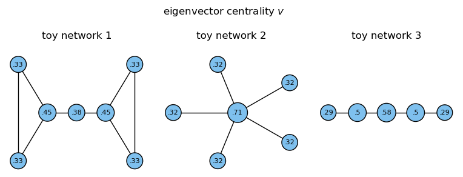

```python
draw_toys(nx.eigenvector_centrality, 'eigenvector centrality $v$')
```

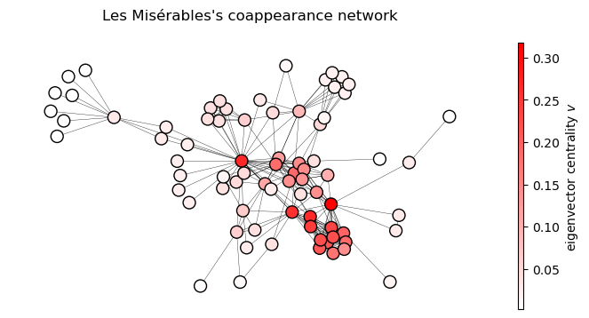

```python
draw_lesmis(nx.eigenvector_centrality, 'eigenvector centrality $v$')
```

### Katz centrality.

Katz centrality $x$ has two equivalent definitions. The first one, as shown on our lecture notes, reads

\begin{align} x_i = \alpha \sum_j A_{ij} x_j + \beta \end{align}

for constants $\alpha\in\left(0,\lambda^{-1}\right)$ and $\beta>0$. Here, $\beta$ represents some non-network factors that can raise a node's centrality, while $\alpha$ controls how much more the factors contribute to the centrality than the node's neigbhours do. If $\beta\to0$, the definition becomes an eigenvector equation and forces $\alpha\to\lambda^{-1}$ as the Perron-Frobenius theorem prescribes. In this sense, Katz centrality reduces to eigenvector centrality, which purely focuses on the gain of centrality due to neighbours, once all non-network factors vanish.

Alternatively, one may write

\begin{align} x_i = \beta \sum_j \sum_{d=0}^\infty \alpha^d \left(\mathbf{A}^d\right) _ {ij} \end{align}

because both definitions yield $\mathbf{x}=\beta\,\left(1-\alpha\mathbf{A}\right)^{-1}\mathbf{1}$ for $\mathbf{x}\equiv\left(x_1\ x_2\ \dots\ x_N\right)^\top$ and a column vector of ones $\mathbf{1}$. In this definition, a node gains centrality by being able to reach many nodes along some paths, but the gain due to long paths (with a long distance $d$) is attenuated by $\alpha$. In addition, the series diverges if $\alpha>\lambda^{-1}$. You can also see that $\beta$ merely scales up everything, so its actual value is not so important and often set to be $\beta=1$.

You can compute Katz centrality with `katz_centrality`, which uses $\alpha=0.1$ and $\beta=1$ by default.

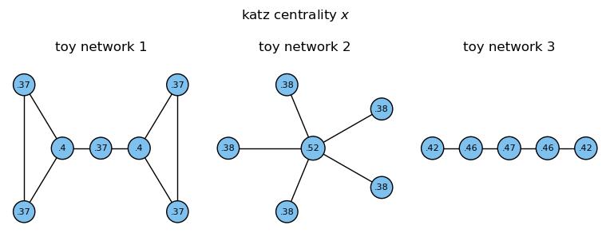

```python
draw_toys(nx.katz_centrality, 'katz centrality $x$')
```

```python
# nx.katz_centrality(lesmis)
# fails because its 1/lambda = .08 < alpha = .1

1/np.linalg.eigvalsh(nx.to_numpy_array(lesmis))[-1]
```

```
0.08329338755898251
```

Finally, in terms of history, Katz invented his centrality using the second definition ([Katz, 1953](https://link.springer.com/article/10.1007/BF02289026)), whereas the first definition was obtained by others later.

# 5. PageRank

We have been so far focusing on centrality measures defined on undirected networks; however, many real networks like the Internet are **directed**. While the previous measures above may be generalized for directed networks, some measures are devoted to quantify centrality on directed networks.

Here I am going to introduce a game-changing quantity, viz. PageRank.

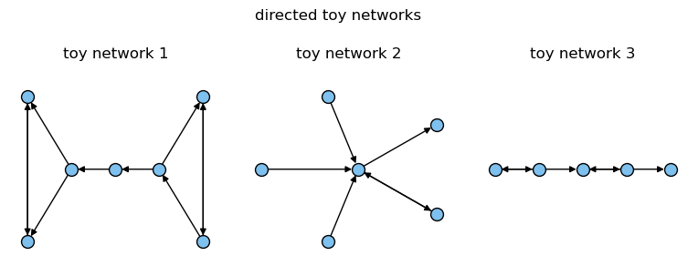

```python
np.random.seed(5056)
toys_directed = []
for toy in toys:
    toyD = toy.to_directed()
    actions = np.random.choice(3, size=toyD.number_of_edges())
    for (u, v), a in zip(toy.edges, actions):
        if a==0: toyD.remove_edge(u, v)
        elif a==1: toyD.remove_edge(v, u)
    toys_directed += [toyD]

draw_toys_directed = lambda cfunc, title: _draw_toys(cfunc, title, toys=toys_directed)
draw_toys_directed(None, 'directed toy networks')
```

PageRank is Google's webpage-sorting algorithm and thus the cornerstone of Google's success. Note that "Page" actually refers to its inventor Larry Page (who is also one of Google's founders) instead of webpages. Node $i$'s PageRank is defined as

\begin{align} p_i = \alpha \sum_j { \dfrac{A_{ji}}{k_j^\text{out}} p_j } + \beta \,, \end{align}

where $k_j^\text{out}=\sum_i{A_{ji}}$ is node $j$'s out-degree. (Remember that $A_{ji}=1$ implies a link from $j$ to $i$.) The definition resembles the eigenvector centrality and Katz centrality: a high-PageRank node has links from some other high-PageRank nodes. You can compute it with `pagerank`.

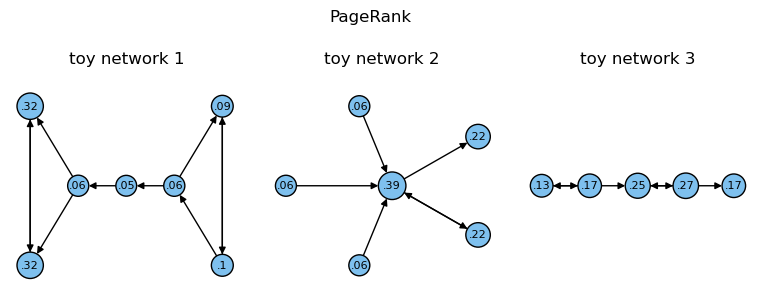

```python
draw_toys_directed(nx.pagerank, 'PageRank')
```

Here are some technical details.

1. The parameter $\alpha\in\left[0, 1\right]$ describes how likely a websurfer clicks a hyperlink on a webpage. It is usually set to be $\alpha=0.85$. If $\alpha=0$, it means that no one clicks to surf at all, giving $p_i\equiv\beta$ and thus equal importance to all webpages.
2. The parameter $\beta$ is usually set as $\beta=\dfrac{1-\alpha}{N}$ so that $\sum_i p_i\equiv 1.$
3. When webpage $j$ has no outward links and thus $k_j^\text{out}=0$, the algorithm links it to all webpages including itself, giving it $A_{ji}\equiv1 \Rightarrow k_j^\text{out}=N$. This means that a websurfer jumps to an arbitrary webpage when he does not see any hyperlinks.

Note that a node's PageRank is almost proportional to its degree on undirected networks ([Gromulsz, 2015](https://www.sciencedirect.com/science/article/abs/pii/S0020019015000381)), so PageRank is useless on undirected networks despite its extraordinary power on directed ones.

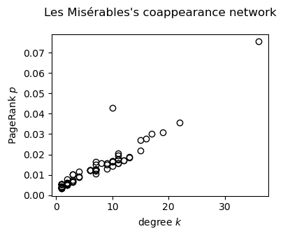

```python
plt.figure(figsize=(4, 3))

plt.plot(dict(nx.degree(lesmis)).values(),
         nx.pagerank(lesmis).values(),
         'ko', markerfacecolor='none')
plt.xlabel('degree $k$')
plt.ylabel('PageRank $p$')
plt.title('Les Misérables\'s coappearance network\n')
plt.show() # more or less proportional on a undirected network
```

# 6. Community

While the previous measures define centrality with **pairwise relationships** betweeen nodes, this section explores an approach based on **communities**, which regards all nodes in a community equally central. Intuitively, a person is important if he belongs to an important community. Still, it is perhaps even more challenging to define "community" than to define "centrality".

One may define a "community" as a "**dense subgraph**" and thus employ tools like components (discussed in Tutorial 2). Here I will introduce two more concepts, viz. cliques and cores. (Later on we will discuss other possible definitions of "community".)

### Clique.

A $k$-clique is a fully connected subgraph with $k$ nodes, and a node's clique nubmer is the size of the largest clique to which it belongs. You can compute a node's clique number with `node_clique_number`. However, the computation becomes extremely expensive as a network grows, so it is barely feasible for real networks.

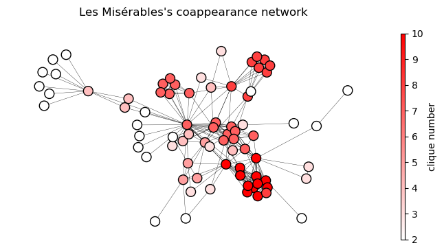

```python
draw_lesmis(nx.node_clique_number, 'clique number')
```

### Core.

Core number (or "coreness") is a more practical alternative. The $k$-core of a network is the largest subgraph in which all nodes' degrees are at least $k$. It can be located easily with the following algorithm.

1. Remove all nodes with degrees less than $k$ and their edges.
2. Update the remaining nodes' degrees.
3. Repeat step 1 until all remaining nodes' degrees are greater than or equal to $k$.

A node's core number $c$ is then the maximum $k$ of all $k$-cores it belongs to. You can compute it with `core_number`.

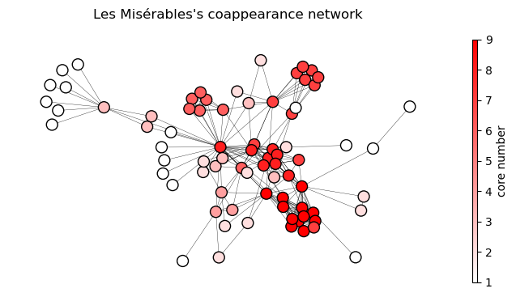

```python
draw_lesmis(nx.core_number, 'core number')
```

# 7. Similarity

Similarity between nodes may also serve as the foundation of centrality. If it is similar to many neighbours, a node is ordinary and has nothing special. In contrast, if it is different from many neighbours, a node is likely extraordinary and thus a possible centre.

There are at least two types of similarity, viz. **structural similarity** and **regular similarity**. It is easier to illustrate them in terms of social networks.

- Two people are structurally similar if they share many common friends. You and your siblings are structrually similar because you share many family members.
- Two people are regularly similar if their neighbours are similar. We are regularly similar because we all know some professors and have some classmates.

Structural similarity directly compares two nodes' neighbourhoods, so it is certainly more intuitive than regular similarity, which is recursively defined like eigenvector centrality.

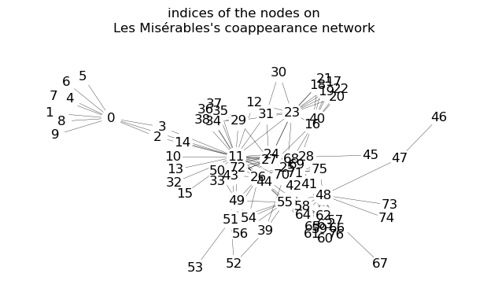

```python
def plot_similarity(similarity_func, label, vmin, cmap):
    ''' similarity_func is a function that receives a graph and
        returns an array S in which S[i, j] is the similarity between i and j
    '''
    plt.figure(figsize=(3, 3))
    plt.imshow(similarity_func(lesmis), cmap=cmap, vmin=vmin, vmax=1)
    plt.xlabel('node $j$')
    plt.ylabel('node $i$')
    plt.title('Les Misérables\'s\ncoappearance network', y=1.04)
    plt.colorbar(fraction=0.045, pad=0.05, label=label)

plt.figure(figsize=(6, 3))
nx.draw(lesmis, pos=lesmis.graph['pos'], node_color='w',
        node_size=300, width=.25, with_labels=True)
plt.title('indices of the nodes on\nLes Misérables\'s coappearance network\n')
plt.show()
```

### Cosine similarity.

There are [many possible measures](https://en.wikipedia.org/wiki/Similarity_measure) for structural similarity, and cosine similarity is an example. The cosine similarity between nodes $i$ and $j$ reads

\begin{align} c_{ij} = \dfrac{\sum_h{A_{ih}A_{jh}}}{\sqrt{\sum_h{A_{ih}^2}} \sqrt{\sum_h{A_{jh}^2}}} = \dfrac{n_{ij}}{\sqrt{k_ik_j}}\,, \end{align}

where $n_{ij}\equiv\sum_h{A_{ih}A_{jh}}$ is the number of their common neighbours.

Its range is $c\in\left[0,1\right]$. As $i$ and $j$ share many neighbours, they are considered similar, and $c_{ij}$ approaches $1$; otherwise, they are considered different, and $c_{ij}$ approaches $0$.

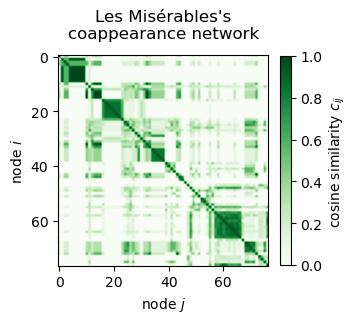

```python
def cosine_similarity(G):
    A = nx.to_numpy_array(G)
    k = A.sum(1).reshape(-1, 1)
    return A@A / np.sqrt(k@k.T)

plot_similarity(cosine_similarity, 'cosine similarity $c_{ij}$',
                cmap='Greens', vmin=0)
```

### SimRank.

SimRank is one of the few examples of regular similarity ([Jeh and Widom, 2002](https://dl.acm.org/doi/10.1145/775047.775126)). The SimRank between nodes $i$ and $j$ reads

\begin{align} s_{ij} = \dfrac{C}{k_ik_j} \sum_u \sum_v A_{iu} A_{jv} s_{uv} \end{align}

for some constant $C\in\left[0,1\right]$. You can compute it with `simrank_similarity`, which sets $C=0.9$ by default.

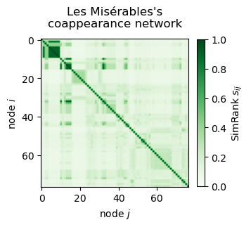

```python
def simrank_similarity(G):
    s = nx.simrank_similarity(G)
    return np.array([list(s[i].values()) for i in s])

plot_similarity(simrank_similarity, 'SimRank $s_{ij}$',
                cmap='Greens', vmin=0)
```

# Closing remarks

NetworkX provides you [numerous kinds of centrality measures](https://networkx.org/documentation/stable/reference/algorithms/centrality.html), while scientists are still keen on inventing novel ones with some creative techniques. All of them are devised to depict certain phenomena, so they are, arguably, all useful in certain scenarios (and useless in others).

Freeman (1978), as a pioneer in the theory of centrality, thus made the following comment:

> The several measures are often only vaguely related to the intuitive ideas they purport to index, and many are so complex that it is difficult or impossible to discover what, if anything, they are measuring.

Well, after learning so many measures, the ultimate lesson is perhaps to remember: [**keep it simple, stupid.**](https://en.wikipedia.org/wiki/KISS_principle)

# References

1. Altmann M. (1993) *Reinterpreting network measures for models of disease transmission*, Soc. Netw. **15**, 1.
2. Freeman L. C. (1978) *Centrality in Social Networks Conceptual Clarification*, Soc. Netw. **1**, 215.
3. Gromulsz V. (2015) *A note on the PageRank of undirected graphs*, Inf. Process. Lett. **115**, 633.
4. Jeh G. and Widom J. (2002) *SimRank: A Measure of Structural-Context Similarity*, in Proc. of the 8th ACM SIGKDD (ACM, NY), 538.
5. Katz L. (1953) *A New Status Index Derived from Sociometric Analysis*, Psychometrika **18**, 39.
6. Knuth D. E. (1993) *The Stanford GraphBase: A Platform for Combinatorial Computing* (Addison-Wesley, Reading, MA).
7. Newman M. E. J. (2005) *A measure of betweenness centrality based on random walks*, Soc. Netw. **27**, 39.
8. Stephenson K. and Zelen M. (1989) *Rethinking centrality: Methods and examples*, Soc. Netw. **11**, 1.